# MNIST Dataset Classification with a Multilayer Perceptron

This notebook gives an example how the MNIST dataset can be classified using a Multilayer Perceptron (MLP) with one hidden layer. Moreover it is using Tensorboard for visualization.

## Data Setup

```python
from tensorflow.examples.tutorials.mnist import input_data
from tensorflow.contrib.tensorboard.plugins import projector
import os

mnist = input_data.read_data_sets('MNIST_data', one_hot=True)

LOG_DIR = "/tmp/mnist/5" #path for tensorBoard

#define paths for embedding
path_for_mnist_sprites =  os.path.join(LOG_DIR,'mnistdigits.png')
path_for_mnist_metadata =  os.path.join(LOG_DIR,'metadata.tsv')
```

## Building the model

A simple model that can be used to classify MNIST images is depicted in the figure below. The model takes the *flat* input image $X$ (the 1D tensors) in its input layer, has one hidden layer with 100 neurons and a rectifier activation function, and a outputlayer with 10 neurons (one for each possible digit). The activation function of the outputlayer is a softmax-function. Therefore, each neuron of the output layer outputs the probability $p(y=j|X)$ that the current input $X$ belongs to the class $j$ represented by this neuron.

[figure not shown]

## Building the Network

```python
import numpy as np
import matplotlib.pyplot as plt
import matplotlib.image as mpimg

import tensorflow as tf
#defining placesholders for input values
with tf.variable_scope("input"):
    x = tf.placeholder(tf.float32, shape=(None, 784))
    y_target = tf.placeholder(tf.float32, shape=(None, 10))
```

```python
#defining placesholders for standardDeviation
stdDeviation = 0.3
w1 = tf.Variable(tf.random_normal([784, 100],stddev=stdDeviation), name="weights1")
b1 = tf.Variable(tf.zeros([100]), name="biases1")

#adding values to tensorboard summary
tf.summary.histogram("weights_1", w1)
tf.summary.histogram("biases_1", b1)

#output layer 1
hiddenLayer = tf.nn.relu(tf.add((x @ w1), b1))
```

```python
w2 = tf.Variable(tf.random_normal([100, 10],stddev=stdDeviation), name="weights2")
b2 = tf.Variable(tf.zeros([10]), name="biases2")

tf.summary.histogram("weights_2", w2)
tf.summary.histogram("biases_2", b2)

outputLogits = tf.add(hiddenLayer@w2, b2) #output of the last layer without activation function
y =  tf.nn.softmax(outputLogits) #final output with activation function
```

```python
# apply activation function (softmax) + loss function (cross entropy)
crossEntropy = tf.nn.softmax_cross_entropy_with_logits_v2(labels=y_target, logits=outputLogits)
averageLoss = tf.reduce_mean(crossEntropy)

tf.summary.scalar("crossEntropy", averageLoss) #adding summary for tensorboard
```

```
<tf.Tensor 'crossEntropy:0' shape=() dtype=string>
```

```python
with tf.variable_scope("learningRatePlaceholder"):
    learningRate = tf.placeholder(
        tf.float32
    )

optimizer = tf.train.GradientDescentOptimizer(learningRate)
minimizer = optimizer.minimize(averageLoss)
```

```python
accuracy = tf.reduce_mean(tf.cast(tf.equal(tf.argmax(y, 1), tf.argmax(y_target, 1)), dtype=tf.float32))
tf.summary.scalar("accuracy", accuracy) #adding summary for tensorboard
```

```
<tf.Tensor 'accuracy:0' shape=() dtype=string>
```

## Training the Model

```python
session = tf.Session()
init = tf.global_variables_initializer()

mergedSummaries = tf.summary.merge_all() #merge accuracy and loss summary

# define writer for tensorboard
writer = tf.summary.FileWriter(LOG_DIR)
writer.add_graph(session.graph)
```

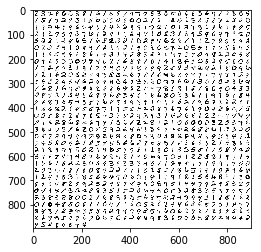

```python
""" EMBEDDING IMPLEMENTATION """

batch_xs, batch_ys = mnist.train.next_batch(1000) #batches for embedding
embedding_var = tf.Variable(batch_xs, name='embedding')

config = projector.ProjectorConfig()
embedding = config.embeddings.add()
embedding.tensor_name = embedding_var.name

#paths
embedding.metadata_path = path_for_mnist_metadata
embedding.sprite.image_path = path_for_mnist_sprites


embedding.sprite.single_image_dim.extend([28,28])

projector.visualize_embeddings(writer, config)


def create_sprite_image(images):
    """Returns a sprite image consisting of images passed as argument. Images should be count x width x height"""
    if isinstance(images, list):
        images = np.array(images)
    img_h = images.shape[1]
    img_w = images.shape[2]
    n_plots = int(np.ceil(np.sqrt(images.shape[0])))


    spriteimage = np.ones((img_h * n_plots ,img_w * n_plots ))

    for i in range(n_plots):
        for j in range(n_plots):
            this_filter = i * n_plots + j
            if this_filter < images.shape[0]:
                this_img = images[this_filter]
                spriteimage[i * img_h:(i + 1) * img_h,
                  j * img_w:(j + 1) * img_w] = this_img

    return spriteimage

def vector_to_matrix_mnist(mnist_digits):
    """Reshapes normal mnist digit (batch,28*28) to matrix (batch,28,28)"""
    return np.reshape(mnist_digits,(-1,28,28))

def invert_grayscale(mnist_digits):
    """ Makes black white, and white black """
    return 1-mnist_digits

to_visualise = batch_xs
to_visualise = vector_to_matrix_mnist(to_visualise)
to_visualise = invert_grayscale(to_visualise)

sprite_image = create_sprite_image(to_visualise)

plt.imsave(path_for_mnist_sprites,sprite_image,cmap='gray')
plt.imshow(sprite_image,cmap='gray')

with open(path_for_mnist_metadata,'w') as f:
    f.write("Index\tLabel\n")
    for index,label in enumerate(batch_ys):
        f.write("%d\t%d\n" % (index, np.argmax(label)))
```

```python
init = tf.global_variables_initializer()
session.run(init)
saver = tf.train.Saver()

for i in range (0, 10000):
    batch_x, batch_y = mnist.train.next_batch(100)
    session.run(minimizer, feed_dict = {x: batch_x, y_target: batch_y, learningRate: 1.})

    if (i % 5 == 0):
        batch_x, batch_y = mnist.test.next_batch(1000) #use test data
        acc, summary = session.run([accuracy, mergedSummaries], feed_dict={x: batch_x, y_target: batch_y, learningRate:1.})

        writer.add_summary(summary, i) #add summary for tensorboard


        if (i % 500 == 0):
            print("Step: ", i, " accuracy: ", acc)
            saver.save(session, os.path.join(LOG_DIR, "model.ckpt"), 1) #saving session for embedding
```

```
Step:  0  accuracy:  0.164
Step:  500  accuracy:  0.936
Step:  1000  accuracy:  0.948
Step:  1500  accuracy:  0.958
Step:  2000  accuracy:  0.969
Step:  2500  accuracy:  0.972
Step:  3000  accuracy:  0.969
Step:  3500  accuracy:  0.952
Step:  4000  accuracy:  0.974
Step:  4500  accuracy:  0.971
Step:  5000  accuracy:  0.971
Step:  5500  accuracy:  0.96
Step:  6000  accuracy:  0.966
Step:  6500  accuracy:  0.959
Step:  7000  accuracy:  0.97
Step:  7500  accuracy:  0.957
Step:  8000  accuracy:  0.966
Step:  8500  accuracy:  0.983
Step:  9000  accuracy:  0.963
Step:  9500  accuracy:  0.97
```

```python
session.close()
```

LeCun, Y., & Cortes, C. (2010). The MNIST database of handwritten digits. Retrieved from http://yann.lecun.com/exdb/mnist

## Conclusion

At first the idea of sessions in Tensorflow is a bit difficult to understand. The fact that sessions are defined first and executed later can make it difficult to debug, especially if one is new to Tensorflow and tries to get log messages while implementing the neural network. But creating a Multi-Layer-Perceptron was rather simple in the end. Only the key functions that define this specific MLP have to be created. The rest is done by Tensorflow by providing many commonly used functions.

When testing our MLP, we gained the following information: After 1000 steps, the accuracy was already at about 95% and increased only marginally over the following increments. It often happens that it actually slightly decreases over some increments. While accuracy is not the only way to measure the performance of a neural network, it works well in our case, since the test data is evenly distributed. We even reached a higher accuracy than expected. This is caused by using a standard deviation of 0.3 when initializing the weights. Unlike defaulting to 1, this initializes the weights with values that are closer to 0. Further decreasing the standard deviation however did not result in a better accuracy. We also used a slightly higher learning rate of 1., which increased the accuracy about one percentage point on average. Again, further increasing the learning rate did not increase the accuracy. To further measure the performance when using different parameters, other metrics like precision, recall and F1-Score should also be taken into account.

These results where found by running the neural network multiple times with different parameters and comparing the accuracy through several iterations. To validate the parameter changes we did to increase the accuracy, we would need to test multiple versions of the trained neural network against a consistent and sufficiently large set of test data.

### Using Visualization

To get a better understanding of the model, we decided to use the visualization tool tensorboard. The board can be opened by using tensorboard --logdir /tmp/mnist/5 and opening http://localhost:6006/

#### Visualizing how our model handles the data

[figure not shown]

The projection tool also shows us, why some digits are classified in the wrong way. For example this "4" has obvious similarities to a "1" why a misclassification is not surprising.

[figure not shown]

#### Developing a better learning rate

As a second step we used tensorboard to develop the "best" learning rate for our model: We ran the session several times with different learning rates (0.001, 0.01, 0.1, 0.5, 1.0) and saved a summary of both accuracy and the loss of our cross Entropy:

[figure not shown]

The results showed us that for our training setup, a learning rate of 1.0 achieves the lowest loss and resulting out of this, the highest accuracy. However the visualization also demonstrates that the effects of learning rates between 0.1 and 1.0, do not differ significantly.

#### Visualizing weights and biases process

We safed the weights and biases during the training in a histogram to evaluate whether they are actually changing during the process.

Value development of the biases and weights of the hidden layer:

[figure not shown]

As depictured the weights are only variating in very small steps wheras the changes of the biases are fluctuating.